# My First Square Roots

### Python as a Calculator

To start, we can use Python as a standard calculator. To do so, we are using the code cell capability of Jupyter. To evaluate a cell, depress the `shift` and `enter` keys. Standard Operations are:

- Multiplication `*`
- Division `/`
- Addition `+`
- Subtraction `-`
- Exponentiation `**`

Examples follow.

```python
2*6
```

```
12
```

```python
9+3
```

```
12
```

```python
15 - 7
```

```
8
```

```python
34/9
```

```
3.7777777777777777
```

```python
4**5
```

```
1024
```

### Variables

To assign a value to a variable, we will use the `=` sign. Once we've assigned a variable, we can operate on the variable just the same as the value itself. Below, we define and operate on a variable named `variable`.

```python
variable = 6
```

```python
variable
```

```
6
```

```python
variable * 3
```

```
18
```

### Lists

A list is an ordered arrangement of things. Each element of a list has a corresponding location. For example, in the list

$$a = [1, 2, 3, 4, 5]$$

1 is the first element, 2 is the second, and so on.

When operating in Python, we will use square brackets `[]` to connote a list.

Further, we will start counting at 0 instead of the familiar 1. For example, if we create the list a as written we have:

```python
a = [1, 2, 3, 4, 5]
```

We have assigned the list to the variable `a`. Now, we can investigate either the entire list, single elements, or slices of the list. Examples follow.

```python
a
```

```
[1, 2, 3, 4, 5]
```

```python
a[0]
```

```
1
```

```python
a[0:3]
```

```
[1, 2, 3]
```

### Lists from Repeated Operations

We will use repeated operations on lists regularly in this class. For example, we could view the list `a` above as starting with 1 and adding 1 to the previous value. Symbolically, I would write:

$$a_0 = 1 \quad a_{i+1} = a_i + 1$$

To accomplish this in python, we will use a `for` loop. A for loop will contain some important pieces of information:

- A number of times to repeat operation
- An operation to repeat on previous terms

First, we can define $a_0$ as the first value in a list as follows.

```python
a = [1]
```

Now, we can create a new variable that will be this first term plus 1.

```python
next = a[0] + 1
```

We can add this value to our list using the `append` function as follows.

```python
a.append(next)
```

Now, we have two elements in the list `a`.

```python
a
```

```
[1, 2]
```

To automate this process, we will use a for loop. The example below will repeat the operation of `+ 1` ten times. This is what the "for i in range(10)" means, and then we tell the loop the operation we want repeated. Here, we will be continually updating and appending our variable `next`.

```python
a = [1]

for i in range(10):
    next = a[i] + 1
    a.append(next)
```

```python
a
```

```
[1, 2, 3, 4, 5, 6, 7, 8, 9, 10, 11]
```

```python
a[0]
```

```
1
```

```python
a[0:5]
```

```
[1, 2, 3, 4, 5]
```

## Plotting with Matplotlib

We will be using the matplotlib plotting library to produce our plots. To make use of this, we will do two things everytime we start a notebook.

1. Tell our notebook to generate plots within the notebook with `%matplotlib inline`
2. Load and abbreviate the plotting library with `import matplotlib.pyplot as plt`

Typically, we will do this in the first cell of the notebook.

```python
%matplotlib inline
import matplotlib.pyplot as plt
```

To create a plot, we will use the `plt.plot()` command. To plot our first sequence, we simply type `plt.plot(a)`.

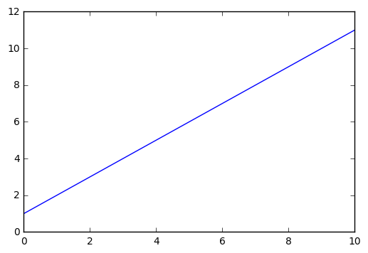

```python
plt.plot(a)
```

Notice that the default behavior is to draw a straight line. We can change this using the marker commands. You can find all markers available and some additional help by typing and executing:

`plt.plot?`

Further, we add a title to our plot with

`plt.title("My First Sequence")`

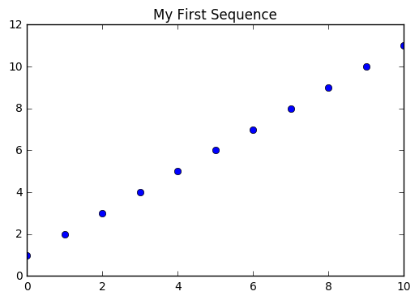

```python
plt.plot(a, 'o')
plt.title("My First Sequence")
```

### Example 2

Below, we create a sequence starting with 1.5 and repeatedly multiplying by 2. We name this sequence `b`, and create a plot that contains both our first and second sequences on the same axes.

```python
b = [1.5]
for i in range(10):
    next = b[i]*2
    b.append(next)
```

```python
b
```

```
[1.5, 3.0, 6.0, 12.0, 24.0, 48.0, 96.0, 192.0, 384.0, 768.0, 1536.0]
```

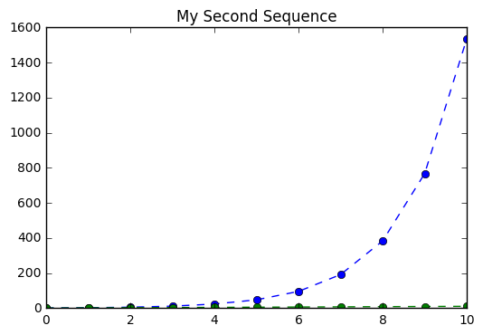

```python
plt.plot(b, '--o')
plt.plot(a, '--o')
plt.title("My Second Sequence")
```

### Assignment

Use what you've learned above to solve the following problems.

1. Generate and plot the first seven terms of the following sequence:

   $$a_0 = 3; a_{i+1} = a_i * \frac{1}{2}$$
2. Generate and plot the first seventy terms of the following sequence:

   $$b_0 = \frac{1}{2}; \quad b_{i+1} = b_i + 0.5^i$$
3. Recall that our square root algorithm was given by the following relationship:

$$x_{i+1} = \frac{1}{2}(x_i + \frac{a}{x_i})$$

where $a$ is the root you are aiming to approximate. Use a loop to approximate and plot the first ten terms of $\sqrt{2}$, starting with $x_0 = 1.5$.

1. Repeat the problem above starting with $x_0 = 10$. Plot these sequences together and write a sentence below describing the difference.
2. Try to further customize your plots by adding $x$ and $y$ labels using the help documentation. Approximate the solution to the equation $x^2 - 2 = 0$ by hand with five iterations of the square root algorithm. Take a picture of this with your cell phone and load it into a markdown cell using either markdown syntax, or the HTML image tag.